# Twitter Report

paul

March 14, 2017

# Twitter API Concepts

### Twitter Intro:

- Structure of data storage is a graph. The graph contains 4 main objects/nodes:
  - [Tweets](https://dev.twitter.com/overview/api/tweets)
  - [Users](https://dev.twitter.com/overview/api/users)
  - [Entities](https://dev.twitter.com/overview/api/entities): metadata and contextual information, such as hashtags, media, url links. Often appears as a field in other objects.
  - [Places](https://dev.twitter.com/overview/api/places): location information associated with endpoints. Tweets can attach places and places can be searched.
- Each object can be referenced by an unique ID.
- Requests are made using HTTP requests.
- **Divided into 2 types of API:**
  - *REST API:* which is used for requesting existing objects within Twitter.
  - *Streaming API:* used for streaming *LIVE* data from the twitter API stream.
- Specific Twitter endpoints support pagination. To request for cursor results, add `&cursor=-1` to the request. If then endpoint/node support cursors, the API will default `cursor` to `-1`. The response value for cursor can be used to navigate for more responses.
  - [Cursors](https://dev.twitter.com/overview/api/cursoring)
- Twitter does an amazing job documenting the [OAuth Request Parameters](https://dev.twitter.com/oauth/overview/introduction). It is highly recommended to view.

### REST API:

- Only takes [Application-Only Authentication](https://dev.twitter.com/oauth/application-only) (requests made on behalf of the application).
- Request format:
  - `https://api.twitter.com/1.1/{endpoints}/{fields}.json?q={query}`
- Rate limited by 15 minute windows, each endpoint/request has varying limitations. Limitation is a cumulative sum. For more information refer to [REST Rate Limit](https://dev.twitter.com/rest/public/rate-limiting)
  - [Rate Limit Table](https://dev.twitter.com/rest/public/rate-limits)
  - GET requests can be made on the behalf of application or user account.
  - HTTP headers are available to request for rate limit information.
- Working with Timelines (like Home page on Facebook):
  - Since timelines are changing in real time, twitter adds parameters to avoid redundant information retrieval.
    - *max_Id*: specifies the to retrieve posts up to and including the max_Id. This will return 1 redundant request. To avoid this, add 1 to the ID of the post (doesn’t matter if the post exists or not).
    - *since_Id*: extract posts after an id.
    - [Details on Working with Timelines](https://dev.twitter.com/rest/public/timelines)
- URLs in twitter are often shortened to “twitter format” but the expanded URL is usually available in the response as well.
- Includes the option to retrieve/post private messages (not very applicable).

#### Search API:

- Essentially the search engine of twitter and will return information from public feed that matches search string.
- This is part of the REST API.
- Provides powerful query formats that can make very interesting queries such as:
  - politics filters: `politics filter:safe`
  - containing media: `puppy filter:media`
  - attitude: `flight:(`
  - hashtags: `#haiku`
- Example Request:‘https://api.twitter.com/1.1/search/tweets.json?q=%40twitterapi’
- [Search API](https://dev.twitter.com/rest/public/search)

### Streaming API:

- [Twitter Stream API](https://dev.twitter.com/streaming/overview)
- This stream provides access to newly updated public tweets data.
- Includes two useful types: *Public* and *User* stream API.
  - [Public Stream](https://dev.twitter.com/streaming/public): Live stream of public posts. *GET* for shorter URL requests while *POST* for longer URLs.
  - [User Stream](https://dev.twitter.com/streaming/userstreams) used to extract a person’s view of twitter: direct messages, replies, following status, etc.
- General process is to establish a connection to the stream API with a request and save the data into a database for future use. The connection is sustained unless error occurs or the user disconnects.
- Does not have normal rate limit caps, however connections will be closed if:
  - attempting to establish too many connections.
  - suddenly stops reading data.
  - reads data at a slow pace such that the queue is filled.
- For more details regarding stalls, reconnecting, etc. Refer to [Connecting to Stream API](https://dev.twitter.com/streaming/overview/connecting)
- Each JSON return will be separated by `\r\n`
- Missing fields will be indicated by a “-1”, use REST API to retrieve information.
- [Stream Message Types](https://dev.twitter.com/streaming/overview/messages-types)
  - will contain blank messages (to sustain connection), delete messages notifications, changes to tweets etc.

### Other APIs/Commercial Usage:

- Twitter REST and Stream API does **not** have a commercial version. The REST and Stream API is to be used as is for commercial purposes. Unlike Facebook API, there is no way to increase the overall rate limit cap. This is because the rate limit is targeted at each user token, thus each user is subjected to its own limits, not the aggregate like facebook.
- [Webhook API](https://dev.twitter.com/webhooks) allows updates/subjects of interest to be posted to an external URL upon verification.
- [Ads API](https://dev.twitter.com/ads) used for managing ads on twitter.

# Account and Access Token

### Test Gmail Account:

- *Name:* API-Testing(first name) NRC(last name)
- *Username/Email:* NRC.API.Testing@gmail.com
- *Password:* NRCTesting123
- *Birthday:* July 1st 1997
- *Gender*: Rather not say

### Twitter Test Account:

- *Username:* NRC API-Testing
- *Email:* NRC.API.Testing@gmail.com
- *Password:* NRCTesting123
- *Twitter Username:* NRC_API_Testing

### Creating Application Access Token:

1: Register on to the [Twitter Application Site](https://apps.twitter.com/).

2: Create a new Application. Fill in a placeholder for the *Website URL*.

3: After creation, click on the “keys and Token” tab and create tokens.

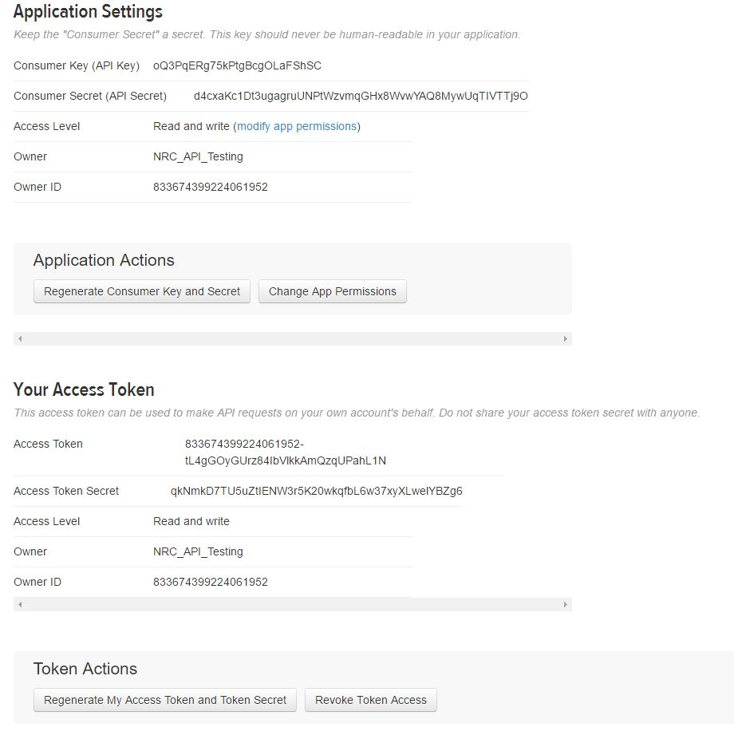

Twitter Token

# Rest API

### Tools and Packages:

- [Apigee Twitter API Console](https://apigee.com/console/twitter)
  - Useful interface to test out queries to the API.
- [twitteR](https://cran.r-project.org/web/packages/twitteR/index.html)
- [twitteR Vignette](http://geoffjentry.hexdump.org/twitteR.pdf)
  - **Highly Recommended to Read**

### Evaluation of *twitteR* and **REST API**:

*Advantages:*

- The built-in class wrappers provides convenient and organized information.
  - functions associated with these class are very useful. like `user$id` etc.
- Even though the package does not support custom requests, most information of interest is provided by default.
- The built-in function for classes provides substantial details and is shown in an easily accessible way.
- Unlike Facebook, many users & tweets are public and thus the account details and **RECENT** tweets are easily accessed.

- The token generated by the package is cached somewhere that can be used by the *twitteR* package functions through out the session. However if another package requires access to the token, it is not easily accessible.
- Tweets are often truncated in response unless specified. The built-in functions does not seem to support extracting untruncated tweets.
- **The Twitter Search API only searches against a sampling of recent Tweets published in the past 7 days. To search for old tweets becomes diffcult.**

### Tweeter Limits And Information:

- Can extract up to a maximum 3200 statuses from a user Timeline.
  - Each page of response can contain up to 200 results.
- For search/tweets, each page of response can contain up to 100 tweets.
- The *source owner* is mentioned in the text of the tweet (status in twitteR package) by an _@_ sign followed by the source owner of the tweet.
- URLs are often reported in twitter short hand, *twitteR* provides functionality to expand into URL and vice-versa.

### Example 1: Creating a Word Cloud From Twitter

**GOAL: To test out the *twitteR* package’s ability to scrape public twitter data.**

- [Google Building wordCloud](https://sites.google.com/site/miningtwitter/questions/talking-about/wordclouds/wordcloud1)
- [Building wordCloud](https://www.r-bloggers.com/building-wordclouds-in-r/)
- [Using tm Package](https://cran.r-project.org/web/packages/tm/vignettes/tm.pdf)

1: Import Libraries

```r
    rm(list = ls())

    library(twitteR)
    library(httr)

    library(tm)
    library(wordcloud)
    library(SnowballC)
    library(RColorBrewer)
```

2: Getting Access Token:

```r
    # access Tokens
    consumer_Key = "oQ3PqERg75kPtgBcgOLaFShSC"
    consumer_Secret = "d4cxaKc1Dt3ugagruUNPtWzvmqGHx8WvwYAQ8MywUqTIVTTj9O"
    access_Token = "833674399224061952-tL4gGOyGUrz84IbVlkkAmQzqUPahL1N"
    access_Secret = "qkNmkD7TU5uZtIENW3r5K20wkqfbL6w37xyXLwelYBZg6"


    ##  Intially, the function asks the user to cache the credentials and
    ##  will be used for another session.
    setup_twitter_oauth(consumer_Key,consumer_Secret,access_Token,access_Secret)
```

```
## [1] "Using direct authentication"
```

```r
    ##  Creating a token manually
    app <- oauth_app("twitter", key=consumer_Key, secret=consumer_Secret)

    token = Token1.0$new(endpoint = NULL, params = list(as_header = TRUE),
                                app = app, credentials = list(oauth_token = access_Token,
                      oauth_token_secret = access_Secret))
    saveRDS(token,"tokenTest")
    test_Token = readRDS("tokenTest")
```

3: Getting Raw Data

```r
    ##  Some parameters
    search_String = "NRC+OR+#NRC+OR+@NRC"
    lang = "en"
    since = "2016-01-01"


    ##  Extracting coordinates for center of Canada:
    google_Api_Key = "AIzaSyBGTs-gZCbyP8n0Hvw_VZ76Z6YrST1DNa8"
    google_Host = "https://maps.googleapis.com/maps/api"

    request = paste(google_Host,"/geocode/json",
                    "?address=Canada&key=",
                    google_Api_Key,sep="")
    raw= GET(request)

    data = jsonlite::fromJSON(
       httr:: content(raw,as="text")
        )
    lat = data$results$geometry$location["lat"]
    lng = data$results$geometry$location["lng"]

    geocode =paste(lat,lng,"2000km",sep=",")



    ##  A list of tweets in Ottawa mentioning NRC. Note, the return
    ## already a "status"
    NRC_Search = searchTwitter(search_String, n=200,
                               lang=lang, since=since,geocode =geocode)
    ##  built in functions allow the specification of "untruncated tweets"
    ##  This was done manually.


    ##  Many tweets are truncated. Getting a list
    ## of ids for tweets that have been truncated.

    truncated_Id = lapply(NRC_Search, function(x)
            {
                if(x$truncated)
                   return(x$id)
                else
                    return(NA)
            }
        )

    version = 1.1
    cmd = "/statuses/show/"
    param = "?tweet_mode=extended"

    search_Id = truncated_Id[
        !is.na(truncated_Id)]

    long_Tweet = list();

    ##  Getting Untruncated tweets
    ##  Going to use the GET method
    for(i in 1:length(search_Id))
    {
        url = paste("https://api.twitter.com/",
                    version,cmd,
                    search_Id[i],".json",
                    param, sep="")

        ##getting raw response
        raw_Response = GET(url,config=token)

        ##  expanded
        long_Tweet[[i]] = jsonlite::fromJSON(
            httr::content(raw_Response,"text")
        )

    }


    truncated_Id[!is.na(truncated_Id)] = long_Tweet

    ## Organized texts results
    for(i in 1:length(NRC_Search)){
        if(NRC_Search[[i]]$truncated){
            NRC_Search[[i]] = truncated_Id[[i]]

        }
    }


    ## removing twitter links
    text_NRC = lapply(NRC_Search, function(x)
            {
                text = x$text
                ## converting to ASCII
                text= iconv(x=text,from="UTF-8",to="ASCII",sub="")

                ##Clearing out URLs
                text=gsub("http(s?)://t.co/[a-zA-Z0-9]+",
                     "",text)
                text=gsub("\nhttps:","",text)
            }
        )



     # rm(list = setdiff(ls(),c("token","text_NRC")))
```

4: Make the word Map

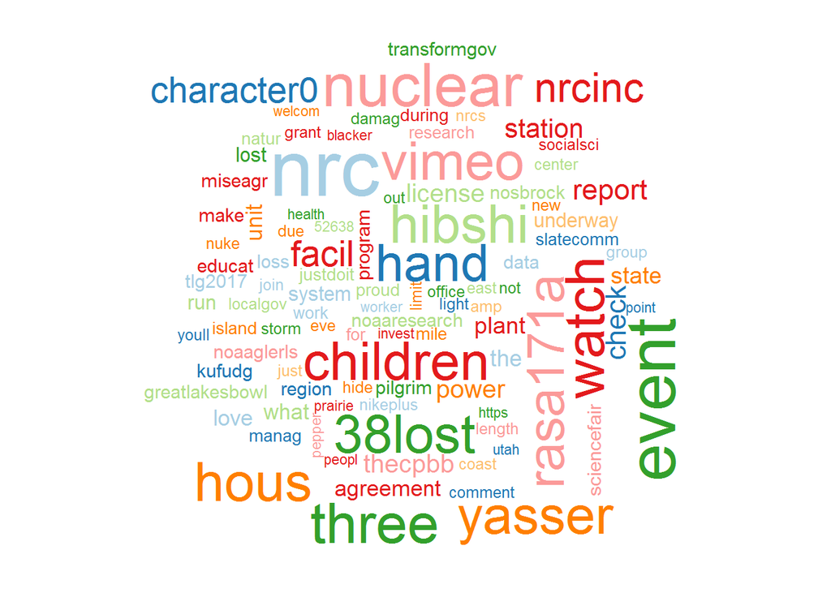

```r
    require(twitteR)
    ##  Constructing corpus (structure to process text)
    cor= Corpus(VectorSource(text_NRC))
    cor = tm_map(cor,removePunctuation)
    cor = tm_map(cor, removeWords,stopwords('english'))
    cor = tm_map(cor,stemDocument)



    ## Some words may appear to be missing characters
    ## This is due to the stem analysis function.

    wordcloud(cor,max.words = 100,random.color=T,random.order = T,
              colors =brewer.pal(8,"Paired") )
```

### REST API Example 2: Random Exploration

- The code for testing is not shown, refer to markdown documents for the code.

```r
    ## Useful for examining rate late
    ## remaining in 15 window
    rate_Limit = getCurRateLimitInfo()
```

1: Friendships, Users and timeline

- **The *lookupUsers* and *friendships* function behaves as specified by the documentation.**
- __ The *userTimelines* function allows the extraction of tweets made by *ANY PUBLIC* user, which is very powerful.__

2: Favorites:

- **The *favorites* function behaves as specified by the documentation.**

3: Trending Section of Twitter:

- **the trending section describes the popular live disscussions and behaves as the documentation specifies.**

### Example 3: DataBase Connection Functions of twitteR:

- The functionality provided by twitteR package behaves as the documentation outlines. To view testing code, refer to the *Twitter Rest API.Rmd* file.
- The data written to the database is stored under `DB_Data.txt`

```r
    library(twitteR)
    search_Data = searchTwitter(searchString="sports",n=10,
                                lang="en")

    db_Data = twitteR::twListToDF(search_Data)

      ##sorting text in search_Data
    for(i in 1: length(db_Data$text)){
        db_Data[[i]] = gsub(pattern="\n", replacement = " ",
                            db_Data[[i]])
    }

    if(!file.exists("DB_Data.txt"))
    {
        file.create("DB_Data.txt")

    }

     write.table(db_Data, file="./DB_Data.txt",row.names = F,
                fileEncoding = "UTF-8",sep="\t",col.names=F)
```

- A very simple database containing the 10 tweets from the *db_Data* and stored it in a local sql data base. Commented out because database is on local computer

```r
require(RMySQL)
require(twitteR)
```

```r
    # db_name = "twitterdb"
    # user = "root"
    # host ="localhost"
    # password = "19970728Paul$"
    #
    # ## sets up a connection
    # DBI = register_mysql_backend(db_name,host,user,password)
    #
    # ## returns a list of twitteR status
    # loaded_Data = load_tweets_db(table_name = "status")
    # paste("Length", length(loaded_Data))
```

Storing tweets: Commented out because data base is on local computer.

```r
    # ## Trying to store tweets into the same db:
    #   search_Data2 = searchTwitter(searchString="#glee",n=10,
    #                             lang="en")
    #
    # ## The new data is appended to the bottom
    # store_tweets_db(search_Data2,table_name="status")
    #
    # loaded_Data = load_tweets_db(table_name = "status")
    # paste("Length", length(loaded_Data))
```

### REST API Example 4: Tweets maximum:

**GOAL: Test to see how many tweets can twitter return.**

- The maximum number of tweets is 3200.

### Example 4: Extracting Entities information:

**Goal:** to extract entities information for a single tweet from the search API. + a tweet containing CNN will be searched.

```r
    rm(list = ls())

    ##  libraries
    library(httr)
    library(jsonlite)
    ##  Getting Token (produced earlier):
     test_Token <- readRDS("tokenTest")

    ##  Making the HTTP request URL
     endpoint <- "https://api.twitter.com/1.1/search/tweets.json"
     args <- c(q = "CNN", count = "1", result_type = "mixed")
     request <- paste( endpoint, paste(names(args),args,collapse = "&", sep = "="),
         sep = "?",collapse = "")


     ## Getting raw Response
     raw <- GET(request, config=(token=test_Token))

     if(raw$status_code!= 200){
         warning("Request not successful")
     }

     response <-fromJSON(rawToChar(raw$content))
     names(response)
```

```
## [1] "statuses"        "search_metadata"
```

```r
     ##metadata for tweet
     meta <- response$statuses$metadata

     ## metadata for search query
     query_Meta <- response$search_metadata

     ## Entities information
     entities <- response$statuses$entities


     ## Expanded URL:
     url <- unlist(entities$urls)
     expanded_Url <- url["expanded_url"]

      expanded_Url
```

```
##                                          expanded_url
## "https://twitter.com/i/web/status/854647531229335553"
```

# Stream API

### Summary of streamR:

- provides easy access to the twitter stream API.
- Handles connection, parsing, disconnecting, reconnecting, backing off and writing to a file all in the background

### IMPORTANT NOTE:

- **Make sure that the twitter application has “obb” specified in the call back URL, this will take the user to the authorization page to extract the pin to set up twitter handshake.**
- **It is recommended to store the RAW JSON/XML response into a file and then process it later on to reduce possible delay for streams.**
- **The streaming functions provided by streamR only stores complete tweets and disregards deletion, updates, incomplete posts etc.**
- **User stream returns only data for the authenticated user for this session. Which is the twitter test account for this report. Not much information due to the nature of the account being a test account.**

### libraries

- [streamR:](https://cran.r-project.org/web/packages/streamR/index.html) Handles connecting and extracting information from twitter stream apis.

### Stream Example 1: Public Streams:

Setting up Token: Commented out because it is stored as a file.

Loading access token file:

```r
    ##  The token is stored and read as an R object

    if(!file.exists("stream Token")){
        file.create("stream Token")
        saveRDS(object = my_oauth, file="stream Token")

    }

    token = readRDS("stream Token")
```

Streaming form stream API:

- The streamed data is saved under `tweets_CNN.json`.

```r
    ##Creating a file to store data
    if(!file.exists("tweets_CNN.json")){
        file.create("tweets_CNN.json")

         ## Can be controlled by either number of tweets
        ## and maximum connection time (timeout)

        filterStream( file.name="tweets_CNN.json",
        track="CNN", tweets=10, oauth=token)
    }

    ## reading in saved file, convert it to a data frame.
    ## where each column is a field and each row is a tweet.
    tweets_DB = parseTweets(tweets = "tweets_CNN.json")
```

```
## 8 tweets have been parsed.
```

```r
    names(tweets_DB)
```

```
##  [1] "text"                      "retweet_count"
##  [3] "favorited"                 "truncated"
##  [5] "id_str"                    "in_reply_to_screen_name"
##  [7] "source"                    "retweeted"
##  [9] "created_at"                "in_reply_to_status_id_str"
## [11] "in_reply_to_user_id_str"   "lang"
## [13] "listed_count"              "verified"
## [15] "location"                  "user_id_str"
## [17] "description"               "geo_enabled"
## [19] "user_created_at"           "statuses_count"
## [21] "followers_count"           "favourites_count"
## [23] "protected"                 "user_url"
## [25] "name"                      "time_zone"
## [27] "user_lang"                 "utc_offset"
## [29] "friends_count"             "screen_name"
## [31] "country_code"              "country"
## [33] "place_type"                "full_name"
## [35] "place_name"                "place_id"
## [37] "place_lat"                 "place_lon"
## [39] "lat"                       "lon"
## [41] "expanded_url"              "url"
```

```r
    ## a list where each element is a JSON nested
    ## tweet
    tweets_List = readTweets(tweets="tweets_CNN.json")
```

```
## 8 tweets have been parsed.
```

### Stream API Example 2: UserStream

- The streamed data is saved under `user stream.json`.

```r
    ##  Not much information is provided beacuse
    ##  not many activites of the test account.

    if(!file.exists("user stream.json")){
        file.create("user stream.json")
        userStream(file.name="user stream.json",
               timeout=120,oauth=token)

    }
```